# Identifying a set of candidate SNPs

Author

Juliette Archambeau & Adélaïde Theraroz

Published

July 28, 2023

```r
# function to make the Venn diagrams
make_venndiagram <- function(list_candidates,
                             caption="",
                             label = "both",
                             title=""){

list_candidates %>%
    ggVennDiagram(lty="solid", size=0.2, label = label) +
  scale_fill_gradient2(low = "white", high = 'gray40') +
  scale_color_manual(values = rep("gray80",6)) +
  guides(fill = "none") +
  labs(caption=caption) +
  ggtitle(title) +
  theme(text = element_text(size=16),
        plot.caption = element_text(hjust=0.5, size=rel(1.2))) +
  scale_x_continuous(expand = expansion(mult = .2))
}
```

# 1 GEA methods

Candidate SNPs were identified using different gene-environment association (GEA) methods, which we summarize below.

## 1.1 Redundancy analysis (RDA)

Two RDA models were fitted:

- not accounting for population structure, which we will call *RDA*.
- accounting for population structure by incorporating in the RDA model the three first PCs of the PCA performed on the genomic dataset (not filtered for minor allele frequencies), which we will call *pRDA*.

In this document, we only use RDA candidates that have been identified based on their *extremeness* along a *distribution of Mahalanobis distances* estimated between each locus and the center of the RDA space using a $K$ number of axes (we used $K=2$). This method was used in Capblancq et al. (2020) (see [code](https://github.com/Capblancq/Local-Adaptation-Fagus-sylvatica)) and Capblancq and Forester (2021) ([code](https://github.com/Capblancq/RDA-landscape-genomics)). For that, (1) the Mahalanobis distances were calculated, (2) $p$-values and $q$-values were obtained with the `radapt` function from Capblancq and Forester (2021), and (3) a FDR (False Discovery Rate) threshold of 5% was applied to the $q$-values to identify the outliers.

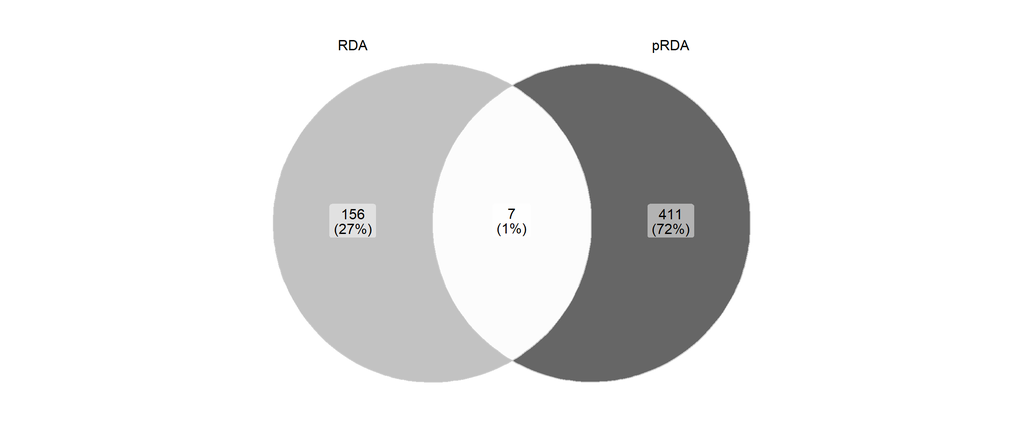

```r
par(mfrow=c(1,2))

rda_outliers <- readRDS(here::here("outputs/RDA/RDA_outliers.rds"))

list_candidates <- list("RDA"=rda_outliers[[1]]$outliers %>% dplyr::filter(maha_meth==T) %>% pull(snp),
                        "pRDA"=rda_outliers[[2]]$outliers %>% dplyr::filter(maha_meth==T) %>% pull(snp))



make_venndiagram(list_candidates[c("RDA","pRDA")])
```

## 1.2 Gradient forest (GF)

Following Fitzpatrick et al. (2021) and Capblancq et al. (2023), GF models were fitted using the ‘raw’ or *uncorrected* allele frequencies.

Threshold: **we use the 0.5% SNPs with the lowest empirical $p$-values.**

```r
list_candidates$"GF"=readRDS(here::here("outputs/GF/gf_outliers.rds"))$outliers_rank005
```

45 candidate SNPs were identified with the GF approach.

## 1.3 Latent factor mixed model (LFMM)

We identified the candidate SNPs by applying a FDR threshold of 5% to the p-values from a LFMM. LFMM was corrected for population structure (ie population relatedness) as the population structure should be captured by the $K$ latent factors ($K = 5$ in our case).

```r
list_candidates$"LFMM" <- readRDS(here::here("outputs/LFMM/candidates.rds"))
```

202 candidate SNPs were identified with the LFMM approach.

## 1.4 BayPass

```r
list_candidates$"BayPass" <- readRDS(here("outputs/BayPass/baypass_outliers.rds"))
```

25 candidate SNPs were identified with BayPass. SNPs were considered as outliers in BayPass when their Bayes factors were higher than 10.

# 2 Common candidate SNPs

Let’s look at the common candidates across the different GEA methods.

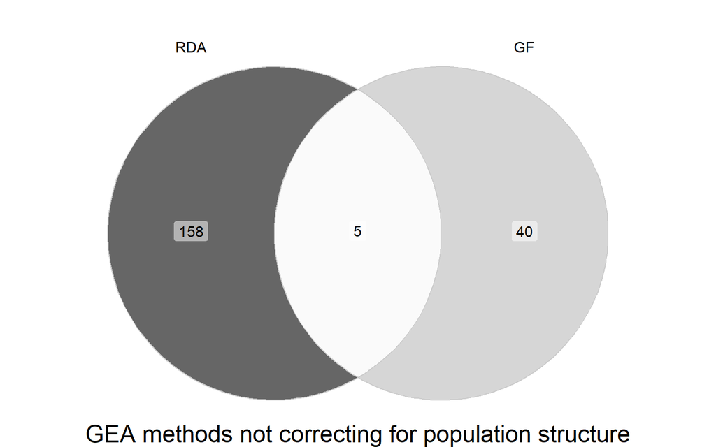

```r
# generating the Venn diagrams showing common candidates across GEA methods
make_venndiagram(list_candidates[c("RDA","GF")],
                 caption = "GEA methods not correcting for population structure",label="count")
```

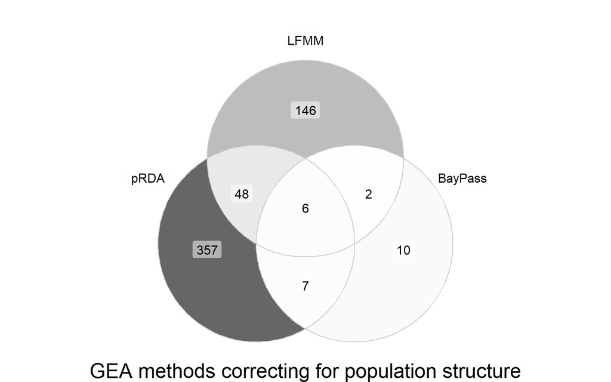

```r
make_venndiagram(list_candidates[c("pRDA","LFMM","BayPass")],
                 caption = "GEA methods correcting for population structure",label="count")
```

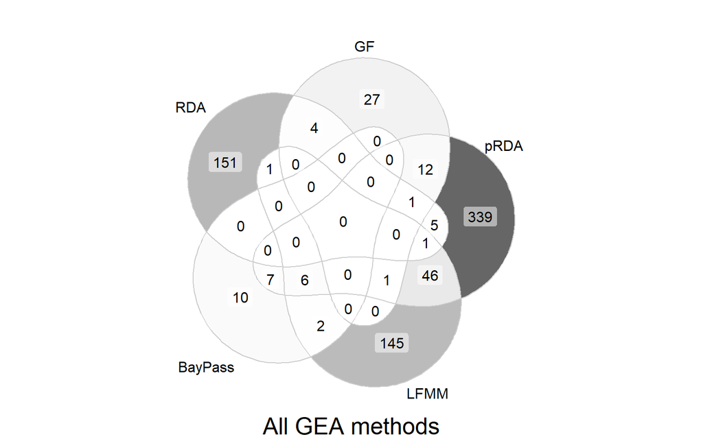

```r
make_venndiagram(list_candidates[c("RDA","GF","pRDA","LFMM","BayPass")],
                 caption = "All GEA methods", label="count")
```

```r
common_snps <- list_candidates %>% unlist() %>% .[duplicated(.)] %>% unique()
```

We select the SNPs identified by at least two methods, which corresponds to 86 SNPs.

# 3 Genome position of candidate SNPs

```r
snppos <- read_excel(here("data/genomic_data/genome_position.xlsx"), sheet = "base_table") %>%
  dplyr::rename(snp_ID = Juliette_snp_ID,
                original_ID = Original_ID,
                affx_ID = affy_snp_id,
                infinium_ID = Infinium_ID,
                genome_position =`position (bp)`,
                annotation =`Annotation (including alternative names)`) %>%
  dplyr::select(snp_ID, original_ID, affx_ID, infinium_ID, scaffold, genome_position, annotation)
```

Information on genome position for the candidates SNPs:

```r
snppos %>%
  dplyr::filter(affx_ID %in% common_snps) %>%
  kable_mydf(boldfirstcolumn = F, font_size = 11)
```

| snp_ID | original_ID | affx_ID | infinium_ID | scaffold | genome_position | annotation |
| --- | --- | --- | --- | --- | --- | --- |
| snp_21 | 0_17206_01.Pipn-297 | Affx-979041075 | SNP_0044 | 0_17206_01_Pipn | 297 | 0_17206_01_Pipn-297 |
| snp_54 | 2_3919_01_contig_refait-268 | Affx-979041132 | SNP_0101 | 2_3919_01_contig_refait | 268 | 2_3919_01_contig_refait-268 |
| snp_82 | 384_COBRA2-335 | Affx-979041178 | SNP_0147 | COBRA2 | 335 | 384_COBRA2-335 |
| snp_136 | AL749660_508 | Affx-979041300 | SNP_0293 | AL749660 | 508 | AL749660_508 |
| snp_137 | AL749660-185 | Affx-979041301 | SNP_0294 | AL749660 | 185 | AL749660-185 |
| snp_528 | BX249686_193 | Affx-979042065 | SNP_1309 | BX249686 | 193 | BX249686_193 |
| snp_759 | BX252245_322 | Affx-979042497 | SNP_1836 | BX252245 | 322 | BX252245_322 |
| snp_843 | BX253195-720 | Affx-979042641 | SNP_2013 | BX253195 | 720 | BX253195-720 |
| snp_1574 | CT576546-673 | Affx-979043917 | SNP_3576 | CT576546 | 673 | CT576546-673 |
| snp_1741 | CT581412-850 | Affx-979044191 | SNP_3890 | CT581412 | 850 | CT581412-850 |
| snp_1916 | F51TW9001AEF8U-201 | Affx-979044475 | SNP_4257 | F51TW9001AEF8U | 201 | F51TW9001AEF8U-201 |
| snp_1946 | F51TW9001AHRMX-71 | Affx-979044531 | SNP_4321 | F51TW9001AHRMX | 71 | F51TW9001AHRMX-71 |
| snp_2050 | F51TW9001B2Z8O-1116 | Affx-979044707 | SNP_4539 | F51TW9001B2Z8O | 1116 | F51TW9001B2Z8O-1116 |
| snp_2051 | F51TW9001B2Z8O-1201 | Affx-979044708 | SNP_4540 | F51TW9001B2Z8O | 1201 | F51TW9001B2Z8O-1201 |
| snp_2158 | F51TW9001C02WO-411 | Affx-979044903 | SNP_4764 | F51TW9001C02WO | 411 | F51TW9001C02WO-411 |
| snp_2240 | F51TW9001DCJIX-290 | Affx-979045046 | SNP_4928 | F51TW9001DCJIX | 290 | F51TW9001DCJIX-290 |
| snp_2241 | F51TW9001DCJIX-73 | Affx-979045047 | SNP_4929 | F51TW9001DCJIX | 73 | F51TW9001DCJIX-73 |
| snp_2257 | F51TW9001E00YW-2335 | Affx-979045072 | SNP_4958 | F51TW9001E00YW | 2335 | F51TW9001E00YW-2335 |
| snp_2276 | F51TW9001ERD0B-1315 | Affx-979045101 | SNP_4991 | F51TW9001ERD0B | 1315 | F51TW9001ERD0B-1315 |
| snp_2278 | F51TW9001ERD0B-942 | Affx-979045103 | SNP_4993 | F51TW9001ERD0B | 942 | F51TW9001ERD0B-942 |
| snp_2437 | FN694439_523 | Affx-979045354 | SNP_5293 | FN694439 | 523 | FN694439-523 |
| snp_2580 | i12003s607pg | Affx-979045591 | SNP_5559 | i12003 | 607 | i12003s607pg |
| snp_2611 | i13311s398pg | Affx-979045645 | SNP_5617 | i13311 | 398 | i13311s398pg |
| snp_2613 | i13452s302pg | Affx-979045648 | SNP_5620 | i13452 | 302 | i13452s302pg |
| snp_2621 | i13871s783pg | Affx-979045661 | SNP_5633 | i13871 | 783 | i13871s783pg |
| snp_2781 | sp_v3.0_unigene10507-1499 | Affx-979045888 | SNP_5878 | sp_v3_0_unigene10507 | 1499 | sp_v3_0_unigene10507-1499 |
| snp_3016 | NA | Affx-979042755 | NA | BX254072 | 662 | BX254072-662 |
| snp_3228 | NA | Affx-979047430 | NA | scaffold_103442 | 1182 | Pinus_pinaster_scaffold_103442_1182 |
| snp_3231 | NA | Affx-979047445 | NA | scaffold_103442 | 1624 | Pinus_pinaster_scaffold_103442_1624 |
| snp_3462 | NA | Affx-979049808 | NA | scaffold_112329 | 973 | Pinus_pinaster_scaffold_112329_973 |

[output cut: 56 more lines]

SNPs on the same scaffold:

```r
snppos %>%
  dplyr::filter(affx_ID %in% common_snps) %>%
  group_by(scaffold) %>%
  filter(n()>1) %>%
  kable_mydf(boldfirstcolumn = F, font_size = 11)
```

| snp_ID | original_ID | affx_ID | infinium_ID | scaffold | genome_position | annotation |
| --- | --- | --- | --- | --- | --- | --- |
| snp_136 | AL749660_508 | Affx-979041300 | SNP_0293 | AL749660 | 508 | AL749660_508 |
| snp_137 | AL749660-185 | Affx-979041301 | SNP_0294 | AL749660 | 185 | AL749660-185 |
| snp_2050 | F51TW9001B2Z8O-1116 | Affx-979044707 | SNP_4539 | F51TW9001B2Z8O | 1116 | F51TW9001B2Z8O-1116 |
| snp_2051 | F51TW9001B2Z8O-1201 | Affx-979044708 | SNP_4540 | F51TW9001B2Z8O | 1201 | F51TW9001B2Z8O-1201 |
| snp_2240 | F51TW9001DCJIX-290 | Affx-979045046 | SNP_4928 | F51TW9001DCJIX | 290 | F51TW9001DCJIX-290 |
| snp_2241 | F51TW9001DCJIX-73 | Affx-979045047 | SNP_4929 | F51TW9001DCJIX | 73 | F51TW9001DCJIX-73 |
| snp_2276 | F51TW9001ERD0B-1315 | Affx-979045101 | SNP_4991 | F51TW9001ERD0B | 1315 | F51TW9001ERD0B-1315 |
| snp_2278 | F51TW9001ERD0B-942 | Affx-979045103 | SNP_4993 | F51TW9001ERD0B | 942 | F51TW9001ERD0B-942 |
| snp_3228 | NA | Affx-979047430 | NA | scaffold_103442 | 1182 | Pinus_pinaster_scaffold_103442_1182 |
| snp_3231 | NA | Affx-979047445 | NA | scaffold_103442 | 1624 | Pinus_pinaster_scaffold_103442_1624 |
| snp_3860 | NA | Affx-979054324 | NA | scaffold_12864 | 2466 | Pinus_pinaster_scaffold_12864_2466 |
| snp_3862 | NA | Affx-979054318 | NA | scaffold_12864 | 1753 | Pinus_pinaster_scaffold_12864_1753 |
| snp_5230 | NA | Affx-979068198 | NA | scaffold_205801 | 275 | Pinus_pinaster_scaffold_205801_275 |
| snp_5240 | NA | Affx-979068204 | NA | scaffold_205801 | 475 | Pinus_pinaster_scaffold_205801_475 |
| snp_6641 | NA | Affx-979083628 | NA | scaffold_35576 | 401 | Pinus_pinaster_scaffold_35576_401 |
| snp_6642 | NA | Affx-979083637 | NA | scaffold_35576 | 545 | Pinus_pinaster_scaffold_35576_545 |
| snp_6643 | NA | Affx-979083644 | NA | scaffold_35576 | 1102 | Pinus_pinaster_scaffold_35576_1102 |
| snp_6644 | NA | Affx-979083655 | NA | scaffold_35576 | 1346 | Pinus_pinaster_scaffold_35576_1346 |
| snp_9344 | NA | Affx-979115701 | NA | scaffold_9766 | 422 | Pinus_pinaster_scaffold_9766_422 |
| snp_9345 | NA | Affx-979115703 | NA | scaffold_9766 | 564 | Pinus_pinaster_scaffold_9766_564 |
| snp_9346 | NA | Affx-979115712 | NA | scaffold_9766 | 1099 | Pinus_pinaster_scaffold_9766_1099 |
| snp_9349 | NA | Affx-979115756 | NA | scaffold_9766 | 2012 | Pinus_pinaster_scaffold_9766_2012 |

**Comment:** a scaffold is a set of contigs separated by gaps and for which the relative orientation and distance is known.

When some SNPs are on the same scaffold, we remove the SNPs with higher $p$-values in the RDA.

```r
snp_to_remove <-  snppos %>%
  dplyr::filter(affx_ID %in% common_snps) %>%
  group_by(scaffold) %>%
  filter(n()>1) %>%
  group_split() %>%
  lapply(function(x){

rda_outliers[[1]]$GSout %>%
   filter(snp %in% x$affx_ID) %>%
   arrange(pvalues) %>%
   slice(2:nrow(x)) %>%
   pull(snp)
      }) %>%
  unlist

common_snps <- setdiff(common_snps, snp_to_remove)
```

After keeping only one candidate SNPs per scaffold, we get 73 candidate SNPs.

```r
common_snps %>% saveRDS(here("outputs/candidate_snps.rds"))
```

## References

Capblancq, Thibaut, and Brenna R Forester. 2021. “Redundancy Analysis (RDA): A Swiss Army Knife for Landscape Genomics.” *Methods in Ecology and Evolution*.

Capblancq, Thibaut, Susanne Lachmuth, Matthew C Fitzpatrick, and Stephen R Keller. 2023. “From Common Gardens to Candidate Genes: Exploring Local Adaptation to Climate in Red Spruce.” *New Phytologist* 237 (5): 1590–1605.

Capblancq, Thibaut, Xavier Morin, Maya Gueguen, Julien Renaud, Stéphane Lobreaux, and Eric Bazin. 2020. “Climate-Associated Genetic Variation in Fagus Sylvatica and Potential Responses to Climate Change in the French Alps.” *Journal of Evolutionary Biology* 33 (6): 783–96.

Fitzpatrick, Matthew C, Vikram E Chhatre, Raju Y Soolanayakanahally, and Stephen R Keller. 2021. “Experimental Support for Genomic Prediction of Climate Maladaptation Using the Machine Learning Approach Gradient Forests.” *Molecular Ecology Resources*.